# Date estimation analysis

#### Single advisor trials

##### Table

| hasFeedback | advisor0idDescription | confidenceChange |
| --- | --- | --- |
| FALSE | Accurate | 0.72 |
| TRUE | Accurate | 0.79 |
| FALSE | Agreeing | 0.71 |
| TRUE | Agreeing | 0.97 |

###### Graph

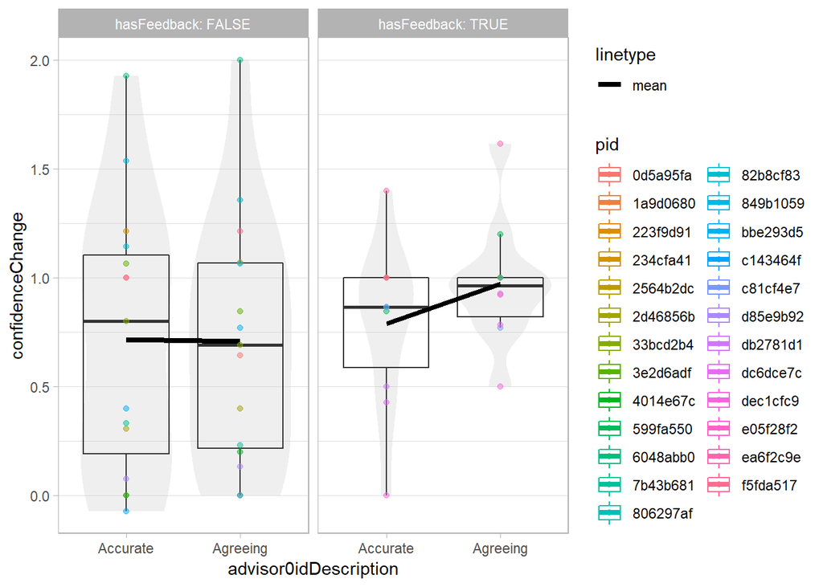

#### Agreement changes

Advisor agreement is calculated using the participant’s initial decision and the advice. In the same way, it is possible to calculate agreement between the advice and the participant’s final decision, and to examine whether this changes (i.e. whether the participant shifts to follow disagreeing advice).

| hasFeedback | agreementChange |
| --- | --- |
| FALSE | 0.29 |
| TRUE | 0.19 |

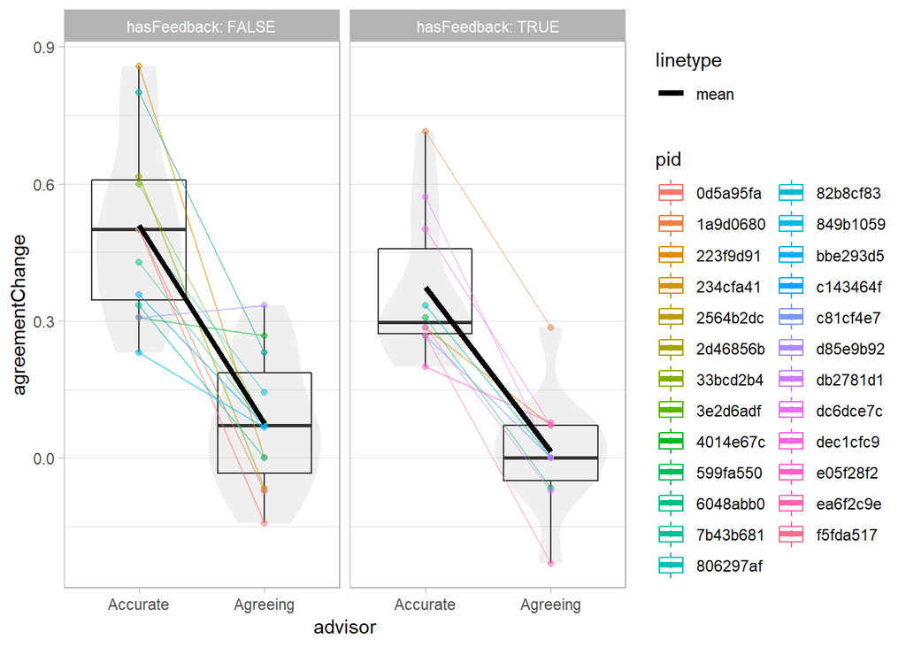

## Hypothesis testing

The hypotheses being tested here are:

1. Participants benefit from advice
   1. when feedback is available
   2. and when feedback is not available
2. Participants use feedback to determine the quality of advice, and thus put more weight on accurate advisors in the feedback condition compared to the no-feedback condition
3. Participants denied feedback use agreement as a proxy for accuracy, and thus put more weight on agreeing advisors in the no-feedback condition compared to the feedback condition

All hypotheses are tested using the trials on which only one advisor provided advice.

### Benefits of advice

Participants should have *lower error on their last decisions than on their first decisions*.

*t*(24) = -10.30, *p* < .001, *d* = 0.97, BF = 37647133.72; *M*|last = 12.92 [11.04, 14.81], *M*|first = 17.83 [15.56, 20.10]

Supporting this primary result, participants should also score *more points on their last answer than on their first answer*, although given that they are allowed to change their confidence, they may sometimes miss the correct answer because they choose a thinner marker.

*t*(24) = 4.04, *p* < .001, *d* = 0.25, BF = 67.02; *M*|last = 2.53 [1.59, 3.48], *M*|first = 1.97 [1.07, 2.87]

The above results could be because participants increase their confidence (i.e. not moving the centre of their marker and therefore not changing the error estimate, but changing the points scored). This can be assessed by looking for differences in correctness.

*t*(24) = 4.64, *p* < .001, *d* = 0.64, BF = 260.01; *M*|last = 0.36 [0.27, 0.44], *M*|first = 0.24 [0.17, 0.31]

#### with feedback

The above effect should hold for participants in the feedback condition.

*t*(9) = -7.92, *p* < .001, *d* = 0.79, BF = 975.19; *M*|last = 13.38 [10.17, 16.58], *M*|first = 17.06 [13.60, 20.53]

And for score as the outcome:

*t*(9) = 4.00, *p* = .003, *d* = 0.34, BF = 16.05; *M*|last = 2.68 [1.03, 4.32], *M*|first = 1.96 [0.61, 3.31]

#### without feedback

The effect should also hold for participants in the no-feedback condition.

*t*(14) = -8.65, *p* < .001, *d* = 1.06, BF = 30235.08; *M*|last = 12.62 [9.99, 15.25], *M*|first = 18.35 [15.02, 21.67]

And for score as the outcome:

*t*(14) = 2.30, *p* = .037, *d* = 0.19, BF = 1.94; *M*|last = 2.44 [1.13, 3.74], *M*|first = 1.98 [0.63, 3.32]

### Weighting of accuracy by feedback

Participants in the feedback condition should have *higher weight on advice for the accurate advisor* than participants in the no-feedback condition.

*t*(22.17) = -4.60, *p* < .001, *d* = 1.79, BF = 106.00; *M*|feedback = 0.44 [0.33, 0.56], *M*|¬feedback = 0.77 [0.66, 0.88]

### Weighting of agreement by feedback

The opposite pattern is expected for the agreeing advisor: feedback should result in *lower weight on advice*.

*t*(19.56) = -2.65, *p* = .016, *d* = 1.08, BF = 3.92; *M*|feedback = 0.34 [0.17, 0.50], *M*|¬feedback = 0.58 [0.45, 0.71]

### General preference

We can also ask which advisor was preferred (if any) by participants in each condition:

Feedback: *t*(9) = -2.21, *p* = .055, *d* = 0.55, BF = 1.64; *M*|agr = 0.34 [0.17, 0.50], *M*|acc = 0.44 [0.33, 0.56]  
No feedback: *t*(14) = -6.66, *p* < .001, *d* = 0.89, BF = 2070.48; *M*|agr = 0.58 [0.45, 0.71], *M*|acc = 0.77 [0.66, 0.88]

### Bayesian ANOVA approach

The questions above can perhaps be more suitably answered using a heirachical Bayesian ANOVA analogue:

```
## Model initializing...
## Compiling rjags model...
## Calling the simulation using the rjags method...
## Burning in the model for 5000 iterations...
## Running the model for 20000 iterations...
## Simulation complete
## Finished running the simulation
## Constructing ANOVA/ANCOVA tables...
## Done...
```

```
## Call:
## BANOVA.Normal(l1_formula = advisor0woa ~ advisor0idDescription,
##     l2_formula = ~hasFeedback, data = tmp, id = tmp$pid)
##
##  Coefficients:
##                                           mean     SD Quantile0.025
## (Intercept)  :  (Intercept)             0.5316 0.0959        0.3405
## (Intercept)  :  hasFeedback1            0.1443 0.0939       -0.0393
## advisor0idDescription1  :  (Intercept)  0.0732 0.0943       -0.1092
## advisor0idDescription1  :  hasFeedback1 0.0213 0.0878       -0.1558
##                                         Quantile0.975 p.value Signif.codes
## (Intercept)  :  (Intercept)                    0.7117 <0.0001          ***
## (Intercept)  :  hasFeedback1                   0.3300  0.1340
## advisor0idDescription1  :  (Intercept)         0.2563  0.4340
## advisor0idDescription1  :  hasFeedback1        0.1948  0.7900
```

#### EZANOVA

Because I don’t quite trust my usage of the BANOVA package above, we’re also looking at this using EZ ANOVA:

```
## $ANOVA
##                              Effect DFn DFd         SSn       SSd
## 1                       (Intercept)   1  23 15.77436425 1.7781746
## 2                       hasFeedback   1  23  0.99131367 1.7781746
## 3             advisor0idDescription   1  23  0.30898487 0.1935147
## 4 hasFeedback:advisor0idDescription   1  23  0.02008966 0.1935147
##            F            p p<.05        ges
## 1 204.035296 6.344667e-13     * 0.88889421
## 2  12.822259 1.582667e-03     * 0.33456385
## 3  36.724093 3.513907e-06     * 0.13547962
## 4   2.387737 1.359400e-01       0.01008629
##
## $aov
##
## Call:
## aov(formula = formula(aov_formula), data = data)
##
## Grand Mean: 0.5616825
##
## Stratum 1: pid
##
## Terms:
##                 hasFeedback Residuals
## Sum of Squares    0.9913137 1.7781746
## Deg. of Freedom           1        23
##
## Residual standard error: 0.2780502
## 1 out of 2 effects not estimable
## Estimated effects are balanced
##
## Stratum 2: pid:advisor0idDescription
##
## Terms:
##                 advisor0idDescription hasFeedback:advisor0idDescription
## Sum of Squares             0.30898487                        0.02008966
## Deg. of Freedom                     1                                 1
##                  Residuals
## Sum of Squares  0.19351470
## Deg. of Freedom         23
##
## Residual standard error: 0.09172613
## Estimated effects may be unbalanced
```

##### Offbrand trials

We suspect clearer results will be obtained using offbrand trials only, but due to there being substantially fewer offbrand than onbrand trials the data are likely to be noisier.

```
## [1] "Dropping incomplete case pid = c81cf4e7"
```

```
## $ANOVA
##                              Effect DFn DFd          SSn       SSd
## 1                       (Intercept)   1  22 21.999719249 2.3379534
## 2                       hasFeedback   1  22  0.903011963 2.3379534
## 3             advisor0idDescription   1  22  0.002634928 0.5473855
## 4 hasFeedback:advisor0idDescription   1  22  0.012175436 0.5473855
##             F            p p<.05          ges
## 1 207.0160278 1.132262e-12     * 0.8840533599
## 2   8.4972880 8.023919e-03     * 0.2383654526
## 3   0.1059006 7.479352e-01       0.0009123796
## 4   0.4893436 4.915511e-01       0.0042020280
##
## $aov
##
## Call:
## aov(formula = formula(aov_formula), data = data)
##
## Grand Mean: 0.6769989
##
## Stratum 1: pid
##
## Terms:
##                 hasFeedback Residuals
## Sum of Squares     0.903012  2.337953
## Deg. of Freedom           1        22
##
## Residual standard error: 0.3259917
## 1 out of 2 effects not estimable
## Estimated effects are balanced
##
## Stratum 2: pid:advisor0idDescription
##
## Terms:
##                 advisor0idDescription hasFeedback:advisor0idDescription
## Sum of Squares              0.0026349                         0.0121754
## Deg. of Freedom                     1                                 1
##                 Residuals
## Sum of Squares  0.5473855
## Deg. of Freedom        22
##
## Residual standard error: 0.1577376
## Estimated effects may be unbalanced
```

### Regressions

We suspect participants responses may be driven by properties of the advice only, while the properties of the advisor are ignored (i.e. participants behave as if all trials are discrete). If this is the case, there will be no differences between regression lines for advisors when regressing predictors vs WoA.

#### Distance x WoA

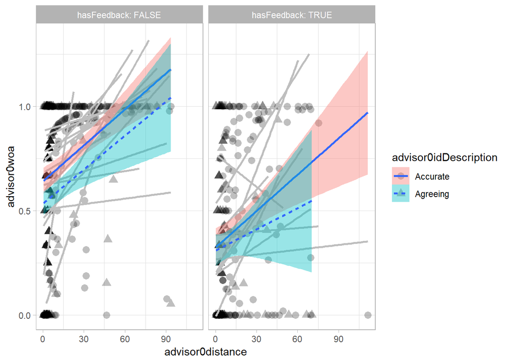

#### Advice error x WoA

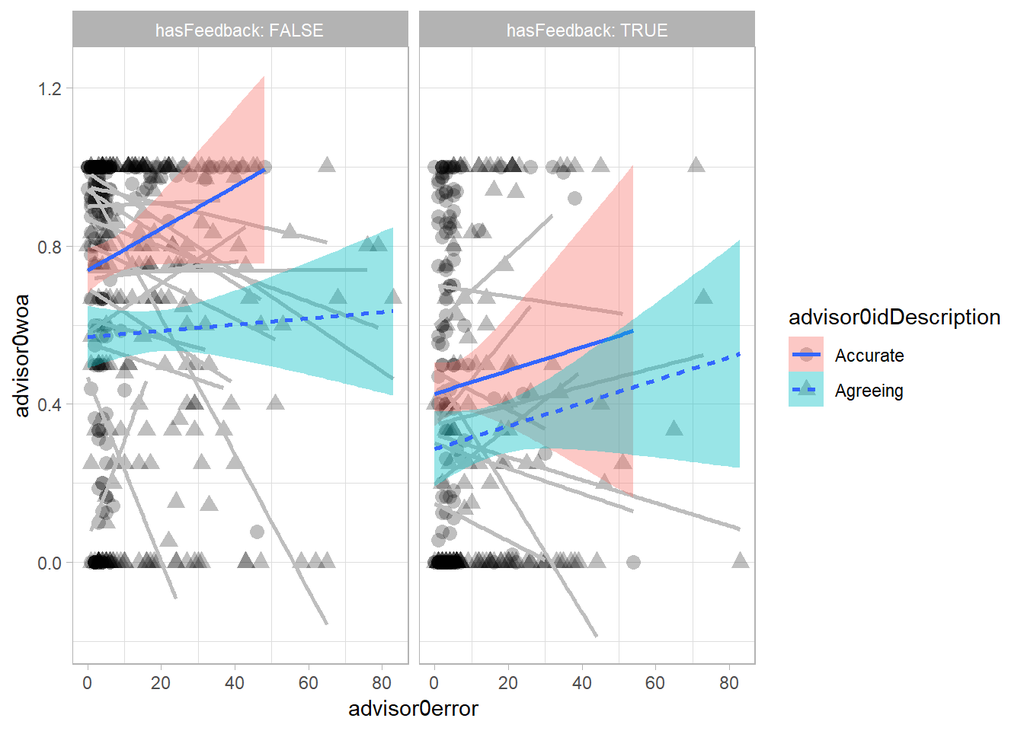

#### Initial decision error x WoA

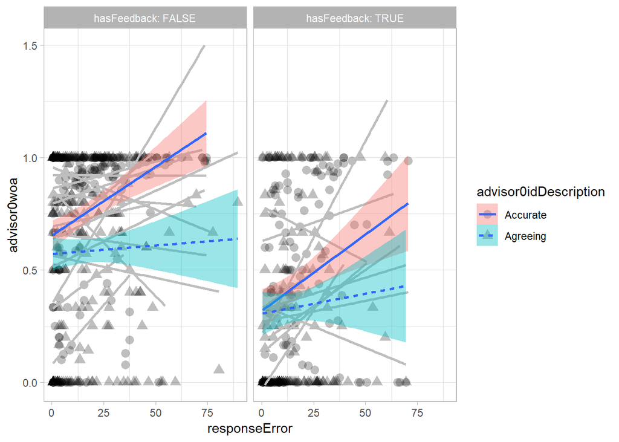

#### Marker width x WoA

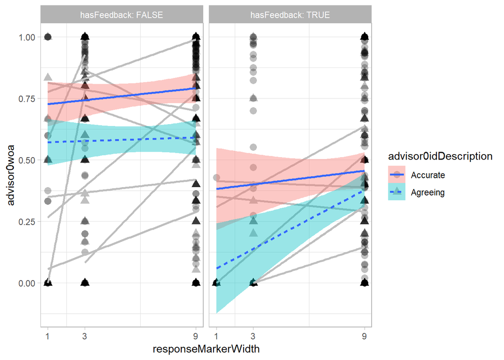

## Update modelling

We can model some of the changes investigated above as a function of the properties of each of the advisors on the trial. These models can be thought of as constituting more specifc hypotheses about the mechanics underlying the updating of advice quality on the basis of experience.

## Credits

### Acknowledgements

Thanks as always to Nick Yeung and the other folks at the [ACC Lab](https://www.psy.ox.ac.uk/research/attention-cognitive-control-lab).

### R Packages

| Package | Citations |
| --- | --- |
| base | R Core Team (2018). R: A language and environment for statistical computing. R Foundation for Statistical Computing, Vienna, Austria. URL https://www.R-project.org/. |
| ez | Michael A. Lawrence (2016). ez: Easy Analysis and Visualization of Factorial Experiments. R package version 4.4-0. https://CRAN.R-project.org/package=ez |
| prettyMD | Matt Jaquiery (2018). prettyMD: Format Test Outputs with Markdown. R package version 0.1.0. |
| knitr | Yihui Xie (2018). knitr: A General-Purpose Package for Dynamic Report Generation in R. R package version 1.20. Yihui Xie (2015) Dynamic Documents with R and knitr. 2nd edition. Chapman and Hall/CRC. I… |
| BANOVA |  |
| BayesFactor | Richard D. Morey and Jeffrey N. Rouder (2018). BayesFactor: Computation of Bayes Factors for Common Designs. R package version 0.9.12-4.2. https://CRAN.R-project.org/package=BayesFactor |
| Matrix | Douglas Bates and Martin Maechler (2018). Matrix: Sparse and Dense Matrix Classes and Methods. R package version 1.2-14. https://CRAN.R-project.org/package=Matrix |
| coda | Martyn Plummer, Nicky Best, Kate Cowles and Karen Vines (2006). CODA: Convergence Diagnosis and Output Analysis for MCMC, R News, vol 6, 7-11 |
| lsr | Navarro, D. J. (2015) Learning statistics with R: A tutorial for psychology students and other beginners. (Version 0.5) University of Adelaide. Adelaide, Australia |
| curl | Jeroen Ooms (2018). curl: A Modern and Flexible Web Client for R. R package version 3.2. https://CRAN.R-project.org/package=curl |
| forcats | Hadley Wickham (2018). forcats: Tools for Working with Categorical Variables (Factors). R package version 0.3.0. https://CRAN.R-project.org/package=forcats |
| stringr | Hadley Wickham (2018). stringr: Simple, Consistent Wrappers for Common String Operations. R package version 1.3.1. https://CRAN.R-project.org/package=stringr |
| dplyr | Hadley Wickham, Romain François, Lionel Henry and Kirill Müller (2018). dplyr: A Grammar of Data Manipulation. R package version 0.7.8. https://CRAN.R-project.org/package=dplyr |
| purrr | Lionel Henry and Hadley Wickham (2018). purrr: Functional Programming Tools. R package version 0.2.5. https://CRAN.R-project.org/package=purrr |
| readr | Hadley Wickham, Jim Hester and Romain Francois (2017). readr: Read Rectangular Text Data. R package version 1.1.1. https://CRAN.R-project.org/package=readr |
| tidyr | Hadley Wickham and Lionel Henry (2018). tidyr: Easily Tidy Data with ‘spread()’ and ‘gather()’ Functions. R package version 0.8.1. https://CRAN.R-project.org/package=tidyr |
| tibble | Kirill Müller and Hadley Wickham (2018). tibble: Simple Data Frames. R package version 1.4.2. https://CRAN.R-project.org/package=tibble |
| ggplot2 | H. Wickham. ggplot2: Elegant Graphics for Data Analysis. Springer-Verlag New York, 2016. |
| tidyverse | Hadley Wickham (2017). tidyverse: Easily Install and Load the ‘Tidyverse’. R package version 1.2.1. https://CRAN.R-project.org/package=tidyverse |
| testthat | Hadley Wickham. testthat: Get Started with Testing. The R Journal, vol. 3, no. 1, pp. 5–10, 2011 |

### Funding

Matt Jaquiery is funded by a studentship from the [Medical Research Council](https://mrc.ukri.org/) (reference 1943590) and the University of Oxford [Department of Experimental Psychology](https://www.psy.ox.ac.uk/) (reference 17/18_MSD_661552).